# noise

1/24/2022

```r
## Setup
library(bdots)

setwd("~/tmp/noise/")
data <- fread("NS1 fh-sh local effect.txt")

## Original fit
fit <- bdotsFit(data = data,
                subject = "subjectID",
                time = "rTime",
                y = "TUR",
                group = c("Condition", "Half"),
                curveType = logistic(),
                cores = 7)

## Refit
new_param <- fread("NS1 fh-sh refit.txt")
refit <- bdotsRefit(fit, paramDT = new_param)

## Bootstrap with refit parameters
boot <- bdotsBoot(formula = diffs(TUR, Condition(Quiet, ExpectNoise)) ~ Half(FH, SH),
                    bdObj = refit,
                    Niter = 1000,
                    alpha = 0.05,
                    padj = "oleson",
                    cores = 7)

## Bootstrap with original fit
boot2 <- bdotsBoot(formula = diffs(TUR, Condition(Quiet, ExpectNoise)) ~ Half(FH, SH),
                  bdObj = fit,
                  Niter = 1000,
                  alpha = 0.05,
                  padj = "oleson",
                  cores = 7)
```

Ok, so this document has a view things:

1. Manually fit bootstrapped curves and differences using the refit parameters (FH, SH, diff of diff)
2. Manually fit bootstrapped curves and differences using the parameters originally returned by `bdotsFit` (FH, SH, diff of diff)
3. Provided both side by side (FH, SH, diff of diff)

Using the original model parameters gives me results closer to what you see in excel. I’m not sure entirely why this is, but I’ll look through the refitting function to see if anything weird is happening. It may be the case in this particular situation that bdots returns better parameter estimates than matlab. Looking at the fit codes between, this seems to hold some weight

```r
table(fit$fitCode)
```

```
##
##   0   1   2
## 131  12   1
```

```r
table(refit$fitCode)
```

```
##
##   0   1   3
## 128  13   3
```

At any rate, feel free to compare these and see if it makes sense. There is an option at the top of the page to download the code that produced this if you want to tweak/make adjustments. There is quite a bit of copy/paste, so hopefully you don’t expect it to look too pretty

# Refit Parameters

Here are results from the bootstrap using the refit parameters

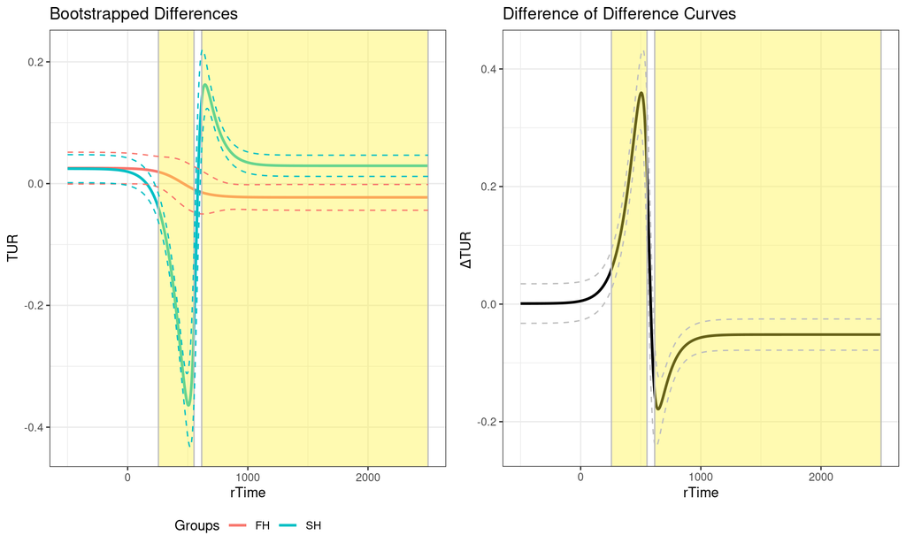

## First Half (refit pars)

Plots of fits for first half, expect noise and quiet, as well as difference between them.

Here, notice that EN is larger than Q until around 200 (this is the 200th time point, not time 200), they cross, with Q being larger. As the difference here is EN - Q, we see that the difference curve starts positive, ends negative.

Also worth noting here is the size of the scale – in the first plot, we see the curves are pretty similar, so the difference between the two isn’t huge. This is reflected in the second plot, where the difference values range between about -0.02 and 0.02

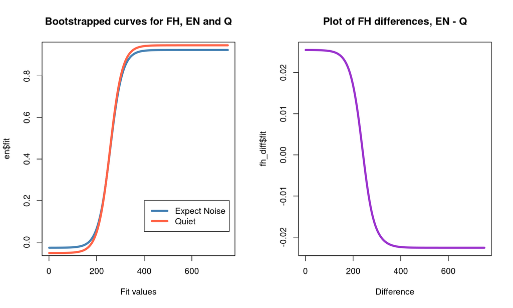

## Second Half (refit pars)

Here is the same for the second half

[figure not shown]

## Difference of Halves (refit pars)

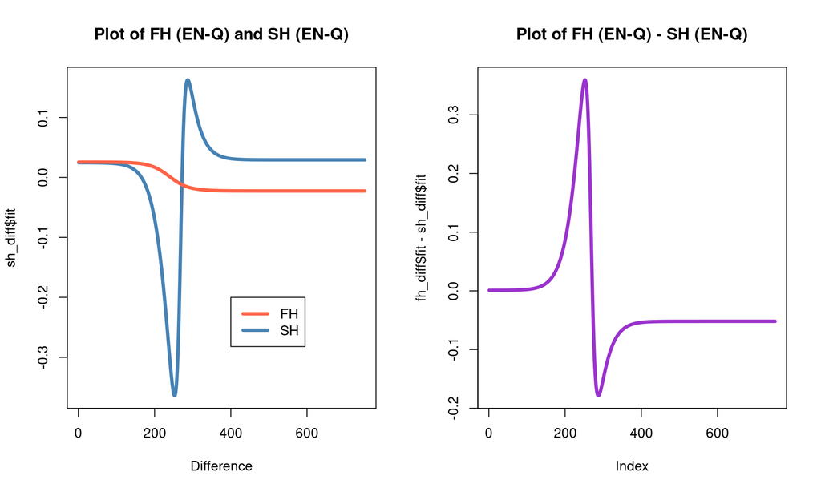

# Original Parameters

Here, I looked at the same thing again but without using the refit parameters. I’ll let you walk through this analysis, it’s similar to above. In the final section, I’ll compare the plots with original and refit side by side

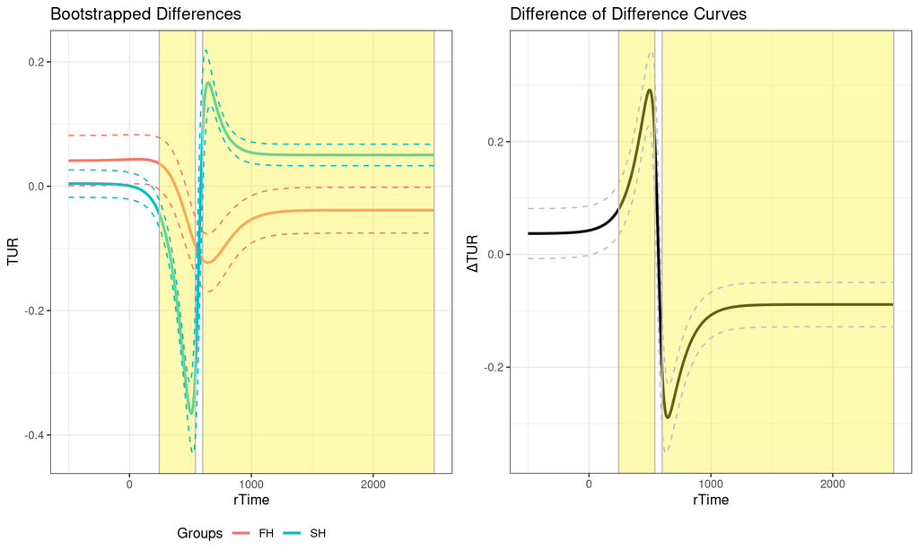

## First Half with original pars

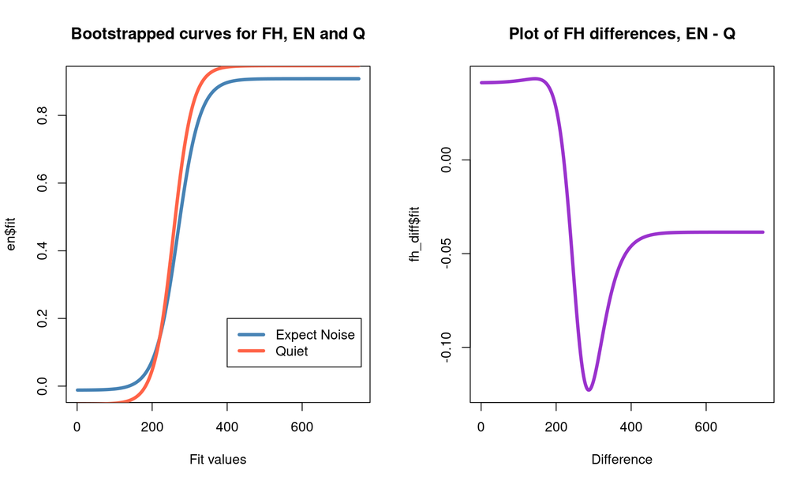

## Second Half with original pars

[figure not shown]

## Difference of Halves with original pars

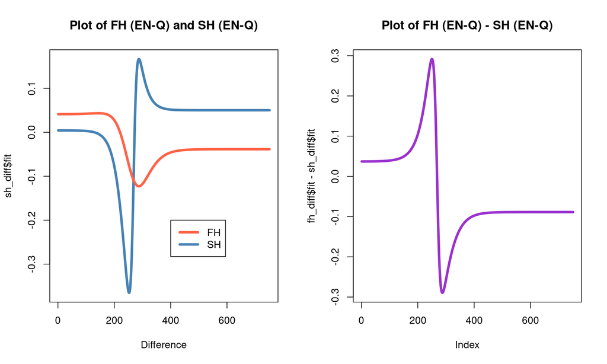

# Comparisons

## First Half (comparison)

Original Fit is the top row, the refit is second row

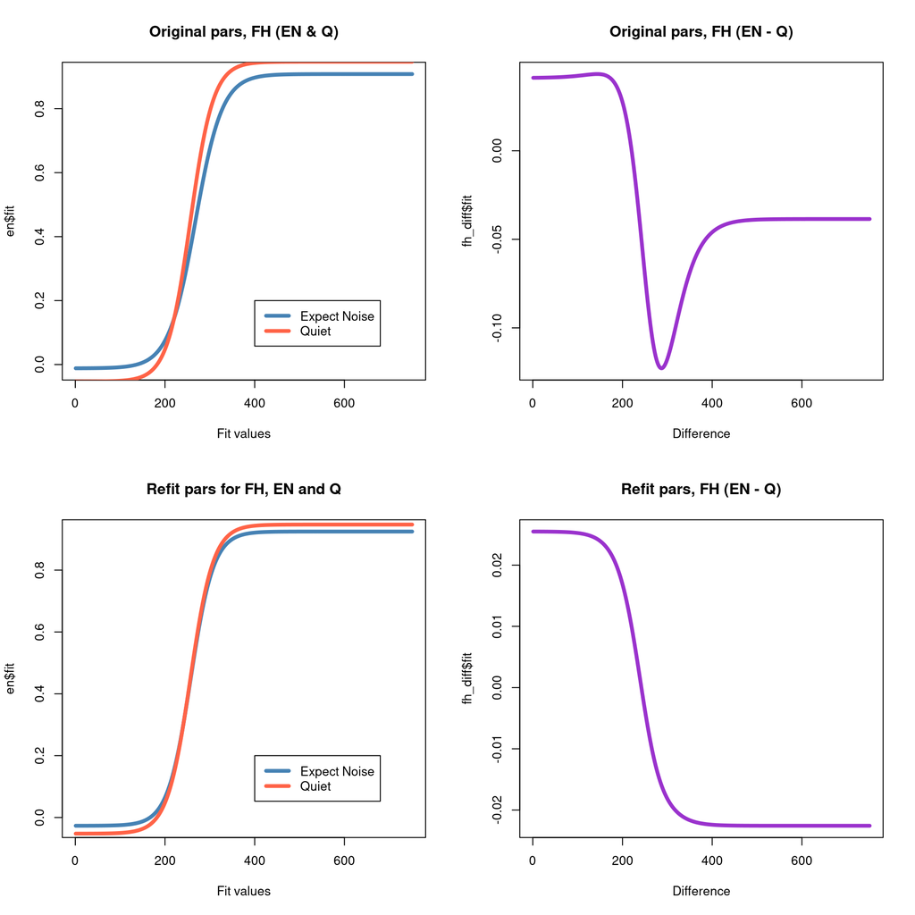

## Second Half (comparison)

[figure not shown]

## Diff of diff (comparison)

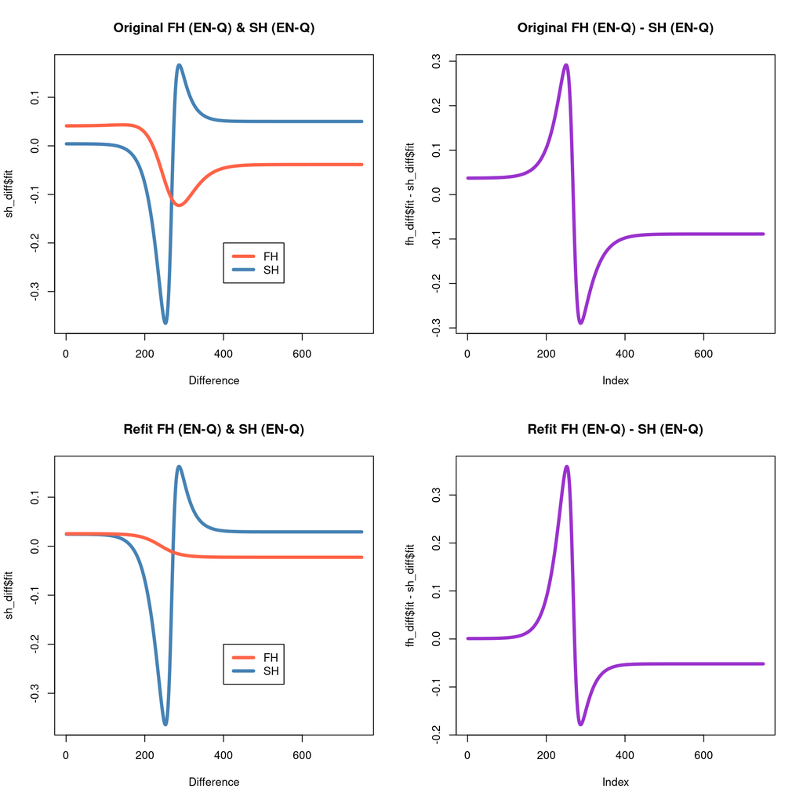